# Primary와 metastatic pancreatic cancer cell의 metastasis gene 발현과 sample collection site에 따른 MMP1 발현 발현 비교

김희연

# 1. 서론

암에 걸려도 기술의 발달로 생존하는 확률이 많이 높아진 현재에도 pancreas cancer는 생존률이 5~10%로 매우 낮다.[^1] 그렇기에 평소에 관심을 가지던 pancreas cancer로 시각화를 하기로 했다. primary pancreas cancer cell과 metastatic pancreas cancer cell에서 metastasis 관련 gene의 발현이 당연히 다르겠지만 나타나는 양상이 궁금했다.

관련 논문을 찾던 중, “Genomics screens for metastasis genes”이라는 논문을 찾았다. 그 논문에서 `Microcell-mediated chromosome transfer` 라는 방법을 통해서 MAP2K4와 KISS1이 metastasis suppressor gene이라는 것을 밝혔다.[^2] `Microcell-mediated chromosome transfer`는 metastasis suppressor gene이 있는 chromosomes를 tumor cell로 넣는 방식이다.[^3] Human/mouse hybrid A9 donor cell과 recipient cell이 합쳐져서 microcell hybrids를 형성한다. 이 microcell들은 donor 및 recipient cell의 염색체 영역의 추가 또는 삭제를 정의하기 위해 cytogenetic method 또는 PCR을 사용하여 특징지어졌다. 이러한 microcell hybrid의 자발적 metastatic ability를 in vivo에서 분석했다.[^4] pancreatic cancer cell에서 MAP2K4는 downregulation되고[^5] KISS1의 overexpression이 metastasis를 막는다고 한다.[^6]

metastasis 과정에 ECM이 매우 중요하므로 관련 gene인 ECM1을 선택하고, 혈관을 만들어서 metastasis가 일어나므로 Vascular Endothelial Growth Factor A를 coding하는 VEGFA를 선택하고, 다른 cacner cell에서 다르게 발현된 MMP1을 선택했다.

논문에서 밝혀진 gene인 MAP2K4와 KISS1과 임의로 선택한 ECM1, VEGFA, MMP1을 가지고 gene expression을 primary pancreatic cancer cell과 metastatic pancreatic cancer cell에서 비교할 것이다.

그리고 두 cancer cell에서 gene expression의 차이가 가장 큰 gene을 가지고 이 gene의 expression이 metastasis 정도에 영향을 주는지 살펴볼 것이다.

# 2. Data Visualization

MAP2K4, KISS1, ECM1, VEGFA, MMP1을 가지고 metastasis가 일어난 cell과 일어나지 않은 cell에서의 gene expression을 비교할 것이다. 첫번째 시각화에서 gene expression 차이가 가장 큰 gene을 가지고 sample collection site에 따른 expression을 볼 것이다.

```r
library(tidyverse)
```

```r
library(ggplot2)
```

## 2.1 Primary와 metastatic pancreatic cancer cell의 metastasis gene 발현

primary pancreatic cancer cell과 metastatic pancreatic cancer cell에서 각 gene별로 boxplot과 violin plot으로 expression의 분포를 살펴본다.

DepMap에서 Cellular Models Expression Public 20Q4와 Cellular Models Cell Line Sample Info를 다운로드하고, load 해준다.

```r
expr = read_csv("C:\\Users\\김희연\\Downloads\\CCLE_expression.csv")
sample = read_csv("C:\\Users\\김희연\\Downloads\\sample_info.csv")
```

`sample`이라는 data frame에서 pancreas cell line을 선택하고, 그 중에서 primary인지 metastasis인지 나오지 않은 cell은 제외한다. 그 후에 primary cancer cell을 골라준다.

```r
pancreas = sample %>%
  filter(lineage == "pancreas") %>%
  filter(!is.na(primary_or_metastasis)) %>%
  pull(DepMap_ID)

pancreas_primary = sample %>%
  filter(lineage == "pancreas" ) %>%
  filter(primary_or_metastasis == "Primary") %>%
  pull(DepMap_ID)
```

`expr` data frame에서 아까 지정한 NA가 없는 pancreas cell line을 선택하고, MAP2K4, KISS1, ECM1, VEGFA, MMP1 gene의 expression만 나타나게 한다. 그리고 plot을 그리기 위해 wide form에서 long form으로 바꿔준다. 위에서 지정해준 `pancreas_primary`로 새로운 column을 만들어서 primary인지 metastasis가 일어난 것인지 나타낸다. boxplot과 violinplot으로 primary와 metastatic pancreatic cancer cell의 gene expression의 분포를 그린다.

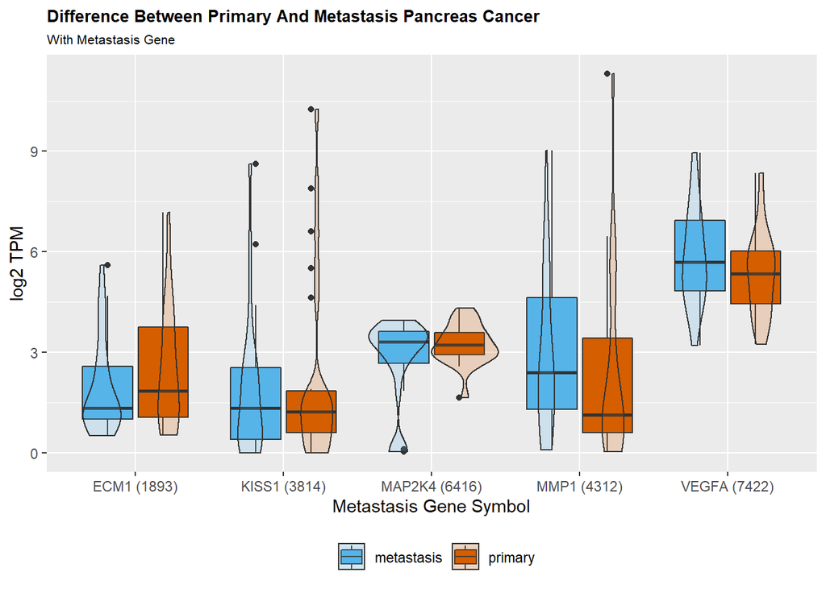

```r
names(expr)[1] = "DepMap_ID"

expr %>%
  filter(DepMap_ID %in% pancreas) %>%
  select(DepMap_ID, `MAP2K4 (6416)`, `KISS1 (3814)`, `ECM1 (1893)`, `VEGFA (7422)`, `MMP1 (4312)`) %>%
  gather(n1, n2, -DepMap_ID) %>%
  mutate(primary_or_metastasis = ifelse(DepMap_ID %in% pancreas_primary, "primary", "metastasis")) %>%
  ggplot(aes(n1, n2, fill = primary_or_metastasis)) +
  geom_boxplot() +
  geom_violin(alpha=0.2) +
  scale_fill_manual(values = c("#56B4E9","#D55E00")) +
  labs(title = "Difference Between Primary And Metastasis Pancreas Cancer",
       subtitle = "With Metastasis Gene") +
  xlab("Metastasis Gene Symbol") +
  ylab("log2 TPM") +
  theme(legend.position="bottom",
        legend.title = element_blank(),
        plot.title = element_text(face='bold', size=10),
        plot.subtitle = element_text(size = 8))
```

gene expression이 log2 TPM으로 나타났다. TPM이란 Transcripts Per Million으로 모든 replicate에 대하여 총 count 수가 normalization 되었기 때문에 각 gene에 어떤 비율로 reads가 있는지 알 수 있다. 즉, gene epxression을 log2 TPM으로 볼 수 있다는 것이다.

시각화를 하기 전에 KISS1은 primary pancreatic cancer cell에서 upregulation되고, MAP2K4는 metastatic pancreatic cancer cell에서 downregulation될 것이라고 예상했다. 하지만 시각화 결과, 논문에 나와있는 metastasis suppressor gene expression의 medain 차이를 보기 힘들다. KISS1은 primary에서 downregulation된 쪽에 치우친 것으로 보이지만, MAP2K4는 metastatic cancer cell에서 median에 몰려있지만 그래도 더 downregulation된 쪽에 cell이 존재하는 것으로 보인다.

ECM1은 primary에서 더 많이 발현되었다고 해석할 수 있지만, MMP1과 VEGFA는 metastatic cancer cell에서 더 많이 발현할 것이라고 예상한 것과 맞아 떨어진다.

GeneCards[^7]에서 이 gene들의 설명을 인용하였다.

> ECM1 : ECM1 (Extracellular Matrix Protein 1) is a Protein Coding gene. Diseases associated with ECM1 include Lipoid Proteinosis Of Urbach And Wiethe and Lichen Sclerosus Et Atrophicus. Among its related pathways are Integrin Pathway and Response to elevated platelet cytosolic Ca2+. Gene Ontology (GO) annotations related to this gene include enzyme binding and protein C-terminus binding.

ECM1은 1q21.2에 위치한다.

> KISS1 : KISS1 (KiSS-1 Metastasis Suppressor) is a Protein Coding gene. Diseases associated with KISS1 include Hypogonadotropic Hypogonadism 13 With Or Without Anosmia and Normosmic Congenital Hypogonadotropic Hypogonadism. Among its related pathways are RET signaling and Signaling by GPCR.

KISS1은 1q32.1에 위치한다.

> MAP2K4 : MAP2K4 (Mitogen-Activated Protein Kinase Kinase 4) is a Protein Coding gene. Diseases associated with MAP2K4 include Ovarian Serous Carcinoma and Cardiomyopathy, Familial Hypertrophic, 25. Among its related pathways are Association Between Physico-Chemical Features and Toxicity Associated Pathways and Apoptosis Modulation and Signaling. Gene Ontology (GO) annotations related to this gene include transferase activity, transferring phosphorus-containing groups and protein tyrosine kinase activity. An important paralog of this gene is MAP2K7.

MAP2K4는 17p12에 위치한다.

MMP1은 11q22.2에 위치한다.

> VEGFA : VEGFA (Vascular Endothelial Growth Factor A) is a Protein Coding gene. Diseases associated with VEGFA include Microvascular Complications Of Diabetes 1 and Poems Syndrome. Among its related pathways are HIF1Alpha Pathway and Cell adhesion_Plasmin signaling. Gene Ontology (GO) annotations related to this gene include protein homodimerization activity and protein heterodimerization activity. An important paralog of this gene is PGF.

VEGFA는 6p21에 위치한다.

gene들의 위치를 확인해 본 결과, 성염색체에 있는 gene이 없기 때문에 성별에 따른 gene expression 차이는 없을 것으로 추측한다.

예상과 일치하는 VEGFA와 MMP1 중 expression의 차이가 primary와 metastasis에서 큰 gene은 MMP1이다. 그래서 MMP1을 가지고 이 gene이 metastasis가 얼마나 일어났느냐에 영향을 주는지 시각화하였다.

## 2.2 Sample collection site에 따른 MMP1 발현

primary와 metastatic pancreatic cancer cell에서 가장 expression의 차이가 많이 나는 MMP1을 가지고 metastasis 정도를 보려고 한다. metastasis 정도는 sample collection site가 pancreas로부터 얼마나 멀리 있느냐로 판단하겠다. 왜냐하면 MMP1이 overexpression될 수록 metastasis 관련 protein이 많이 만들어질 것이고, metastasis 가 더 활발히 일어날 것이다. 결국 온 몸으로 암이 퍼질 것이다. 이 온 몸으로 퍼지는 것에서 따와서 **얼마나 멀리 퍼졌느냐** 로 metastasis 정도를 판단할 것이다.

`sample`에서 2.1에서 지정한 NA가 없는 pancreatic cancer cell을 선택하고 그 중에서 metastatic cancer cell만 남긴다. sample_collection_site와 DepMap_ID의 데이터만 가지는 `sampl_metastasis` data frame을 만들어준다.

```r
sample_metastasis = sample %>%
  filter(DepMap_ID %in% pancreas) %>%
  filter(primary_or_metastasis == "Metastasis") %>%
  select(DepMap_ID, sample_collection_site )
```

metastastic pancreatic cancer cell을 지정해주고, 이를 이용하여 metastatic pancreatic cancer cell의 MMP1 expression을 보여주는 `MMP1_expr` data frame을 만들어준다.

```r
metastasis = sample %>%
  filter(lineage == "pancreas") %>%
  filter(primary_or_metastasis == "Metastasis") %>%
  pull(DepMap_ID)

MMP1_expr = expr %>%
  filter(DepMap_ID %in% metastasis) %>%
  select(DepMap_ID, `MMP1 (4312)`)
```

`expr`과 `sample`에 동시에 존재하지 않는 cell이 있을 수 있으니 `MMP1_expr`의 cell line을 지정해준다. 전에 만들어 놓은 `sample_metastasis` data frame에 방금 지정한 cell line만 선택하고 `MMP1_expr` data frame을 합친다. cell의 개수가 적기 때문에 sample collection site에 따른 MMP1의 expression 분포를 boxplot과 pointplot을 같이 그린다.

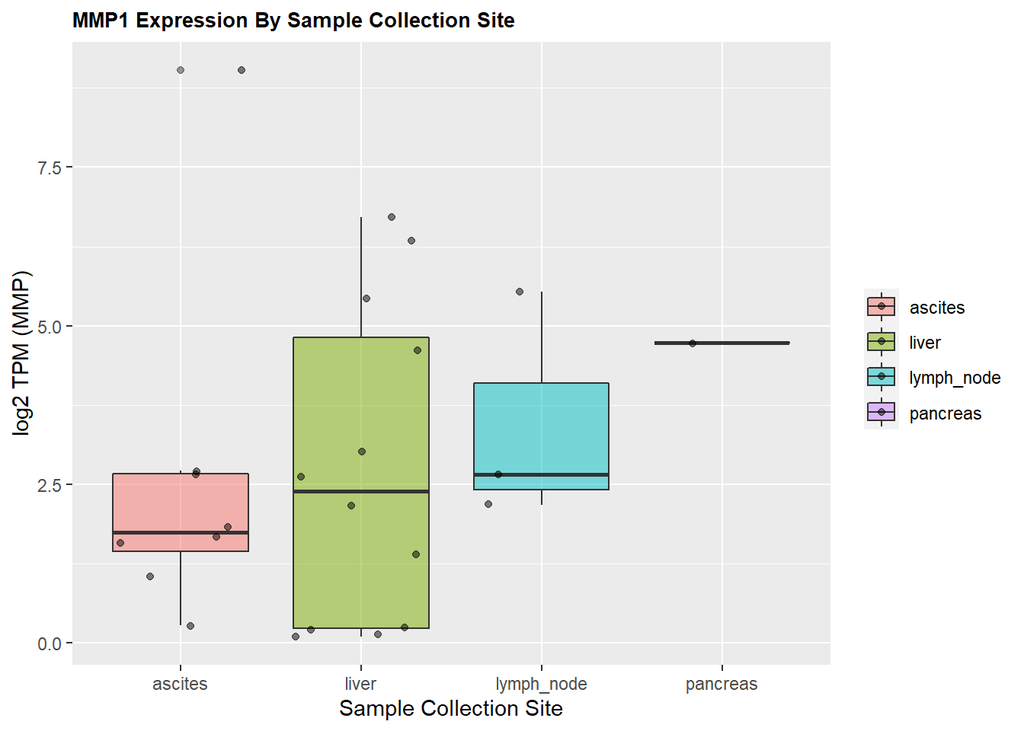

```r
b = MMP1_expr %>%
  pull(DepMap_ID)

merge(sample_metastasis %>%
            filter(DepMap_ID %in% b), MMP1_expr, by = "DepMap_ID") %>%
  ggplot(aes(sample_collection_site, `MMP1 (4312)`, fill=sample_collection_site)) +
  geom_boxplot(alpha=0.5) +
  geom_jitter(alpha=0.5) +
  labs(title = "MMP1 Expression By Sample Collection Site") +
  xlab("Sample Collection Site") +
  ylab("log2 TPM (MMP)") +
  theme(legend.title = element_blank(),
        plot.title = element_text(face='bold', size=10),
        plot.subtitle = element_text(size = 8))
```

# 3. 결론

논문에서 pancreatic cancer cell에서 dysregulation된다고 밝혀진 MAP2K4와 KISS1과 metastasis와 관련된 gene인 ECM1, VEGFA, MMP1을 가지고 gene expression을 primary pancreatic cancer cell과 metastatic pancreatic cancer cell에서 비교했다. 이어서 두 cancer cell에서 gene expression의 차이가 가장 큰 MMP1을 가지고, 이 gene의 expression이 metastasis 정도에 영향을 주는지 살펴보았다.

첫 번째 시각화를 한 결과, 논문에서 dysregulation 된다고 밝혀진 MAP2K4와 KISS1은 분포에서는 살짝 차이가 나지만 median은 거의 같아서 primary와 metastatic cell의 차이가 없는 것으로 보인다. metastasis와 관련된 gene 중 VEGFA와 MMP1은 metastatic pancreatic cancer cell에서 더 많이 발현된다. 가장 발현의 차이가 많이 나는 gene은 MMP1이다.

sample collection site에서 MMP1의 발현을 살펴본 결과, 가장 gene이 많이 발현한 cell은 ascites에서 추출한 것이고, 상대적으로 중간 정도 발현하는 cell은 liver, lymph node에서 추출한 것이고, 적게 발현한 cell은 ascites와 liver에서 추출한 것이다. 전체적인 gene expression 분포는 이러하다. median을 살펴보자면 ascites, liver, lymph node 순으로 발현이 적게 되었다. seed and soil hypothesis에 기반하여 해석하자면 애초에 선호하는 site로 전이되기 쉬운데, protein의 도움이 많이 필요하다면 그 쪽은 선호하지 않는 것이라고 해석하였다. 그래서 ascites, liver, lymph node 순서로 선호한다고 해석하였다. 또한 전이 상태와는 별개로 sample을 추출했다는 결과로 볼 수도 있다.

# 4. Reference

1. Jinchun Yan and Qihong Huang. Genomics screens for metastasis genes.Cancer Metastasis Rev. 2012 Dec; 31(0): 419–428.
2. Fournier RE, Ruddle FH. Microcell-mediated transfer of murine chromosomes into mouse, Chinese hamster, and human somatic cells. Proceedings of the National Academy of Sciences of the United States of America. 1977;74:319–323.
3. Yoshida BA, Sokoloff MM, Welch DR, Rinker-Schaeffer CW. Metastasis-suppressor genes: a review and perspective on an emerging field. Journal of the National Cancer Institute. 2000;92(21):1717–1730.
4. Xin W, Yun KJ, Ricci F, Zahurak M, Qiu W, Su GH, et al. MAP2K4/MKK4 expression in pancreatic cancer: genetic validation of immunochemistry and relationship to disease course. Clinical Cancer Research. 2004;10:8516–8520.
5. McNally LR, Welch DR, Beck BH, Stafford LJ, Long JW, Sellers JC, et al. KISS1 overexpression suppresses metastasis of pancreatic adenocarcinoma in a xenograft mouse model. Clinical & Experimental Metastasis. 2010;27(8):591–600.
[^1]: https://www.hopkinsmedicine.org/health/conditions-and-diseases/pancreatic-cancer/pancreatic-cancer-prognosis
[^2]: https://www.ncbi.nlm.nih.gov/pmc/articles/PMC4071451/
[^3]: https://pubmed.ncbi.nlm.nih.gov/264685/
[^4]: https://pubmed.ncbi.nlm.nih.gov/11058615/
[^5]: https://pubmed.ncbi.nlm.nih.gov/15623633/
[^6]: https://www.ncbi.nlm.nih.gov/pmc/articles/PMC2975384/
[^7]: https://www.genecards.org/